# Bike Sharing Trends of Ford GoBike System

### By Edwin Aquino

**Instructions for creating slide deck**

1. Be sure you have a copy of output_toggle.tpl file in this current directory
2. Run the following shell command to create a slide deck:

`jupyter nbconvert Bike_Share_Part2_Explanatory.ipynb --to slides --post serve --template output_toggle`

## Investigation Overview

In this investigation I wanted to look into how this new form of ride sharing system that has enabled people in the bay area to make use of the service for commuting purposes.

## Dataset Overview

The data consisted of over 2 million records. The attributes included member's gender, birth year, membership type, trip locations and times. Additional columns were added to deeply visualize data further.

```python
# Include required libraries for this project
from os import path, getcwd, makedirs, listdir
from io import BytesIO # for zip files
from zipfile import ZipFile
import pandas as pd
import numpy as np
import matplotlib
from matplotlib import pyplot as plt
import matplotlib.ticker as tick
import seaborn as sns
import datetime
import time
import calendar
import warnings
import requests
from pathlib import Path
#warnings.filterwarnings('ignore') - only show errors
from IPython.display import Image
%matplotlib inline
import warnings
warnings.filterwarnings('ignore')
# Display progress bar
from ipywidgets import FloatProgress
from IPython.display import display, clear_output
```

```python
# load in the dataset into a pandas dataframe
csv_files_dir = 'data_files/'
df_copy_file_name = csv_files_dir+"backups/FINAL_df_copy.csv"
if path.exists(df_copy_file_name):
    print('Loading dataframe file, Please Wait....')
    start = time.time()
    df_copy = pd.read_csv(df_copy_file_name )
    end = time.time()
    exec_time = (end - start) / 60
    clear_output()
    print("[SUCCESS] df_copy file has been loaded.\nTotal Execution Time: " +format(exec_time, '.0f') + " minutes")
else:
    print("[ERROR] File:", df_copy_file_name, ' Not Found.')
```

```
[SUCCESS] df_copy file has been loaded.
Total Execution Time: 1 minutes
```

```python
# Confirm DataFrame is loaded
df_copy.shape
```

```
(2383421, 37)
```

## Age Distribution of Users

> A large percentage of bike users are from the age of 18 to 55. The rest of the users consist of incorrect data as some users show more than 100 years old.

```python
plot_color = sns.color_palette()[0] # blue color
def Age_Distrubition_Users():
    plt.figure(figsize=(10,6))
    sns.boxplot(x='member_age', data=df_copy, palette='Blues', orient='h',color=plot_color)
    plt.title("Ege Distribution of Ford GoBike Members", fontsize=20, y=1.03)
    plt.xlabel("Member Age", fontsize=18, labelpad=10)
```

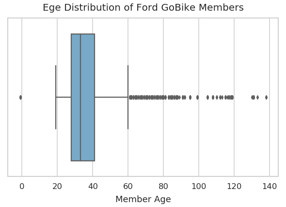

```python
Age_Distrubition_Users()
```

## Monthly Ride Habits by User Type

```python
def Monthly_Ride_Habits_User_Type():
    # Monthly Bike Share Usage by User Type
    g = sns.catplot(data=df_copy, x='start_time_month', col="user_type", kind='count', sharey = False, color = plot_color)
    g.set_axis_labels("Month", "Number of Rides")
    g.set_titles("{col_name}")
    g.fig.suptitle('Monthly Bike Share Usage by User Type', y=1.03, fontsize=15, fontweight='semibold');
```

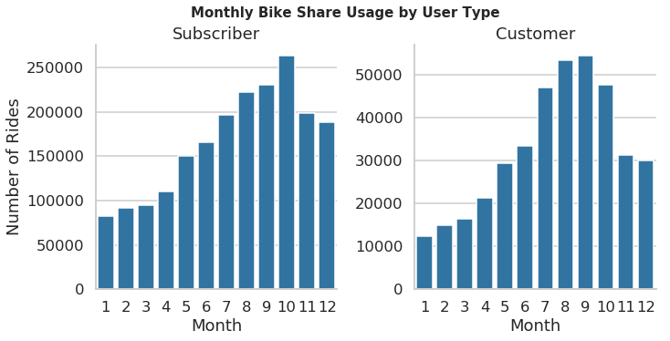

```python
Monthly_Ride_Habits_User_Type()
```

## Weekly Ride Habits by User Type

- The majority of riders use the service for communizing to and from work. Peak days are Monday through Friday.
- For customers is quite the opposite, weekends seem to be the two peak day. Most tourist are around and about enjoying the amazing sites in the Bay Area.

```python
def Weekly_Ride_Habits():
    # Weekly Bike Share Usage by User Type
    days = [ 'Sun','Mon', 'Tue', 'Wed', 'Thu', 'Fri', 'Sat']
    g = sns.catplot(data=df_copy, x='start_time_week_abbr', col="user_type", kind='count', sharey = False, color = plot_color, order = days)
    g.set_axis_labels("Day of the Week", "Number of Rides")
    g.set_titles("{col_name}")
    g.fig.suptitle('Weekly Bike Share Usage by User Type', y=1.03, fontsize=15, fontweight='semibold');
```

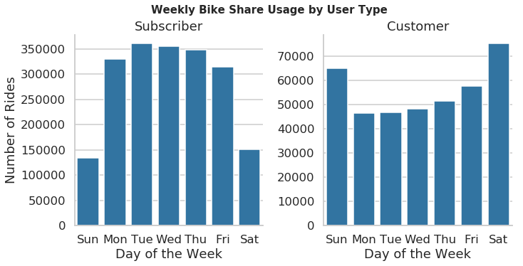

```python
Weekly_Ride_Habits()
```

## Distribution of Monthly Age Groups

This graph shows riders in the 30-40 age group to be the most active. I expected the 20-30 age group to be more active riders. Once possible reason why you see the 30-40 age group is because the service is very popular with commuters. Commuters tend to be individuals with work and more predictable bike riding habits.

```python
# This function will be use to plot graphs.
def change_axis_format(tick_val, pos):
    if tick_val >= 1000:
        val = int(tick_val/1000)
        return '{:d}K'.format(val)
    elif tick_val >= 1000000:
        val = int(tick_val/1000000)
        return '{:d}M'.format(val)
    else:
        return int(tick_val)
```

```python
def Distribution_Monthly_Age_Groups():
    # Monthly trend of bike rides for 20 to 50 years olds
    plt.figure(figsize=(15,8))
    my_palette = {'20 - 30': 'darkblue', '30 - 40': 'c', '40 - 50': 'crimson'}
    member_age_data = df_copy[df_copy['member_age_range'].isin(['20 - 30', '30 - 40', '40 - 50'])].sort_values(by=['start_time_year_month_new', 'member_age_range'])
    ax = sns.countplot(x='start_time_year_month_new', hue='member_age_range', palette=my_palette, data=member_age_data)
    plt.title('Monthly trend of bike rides for 20 to 50 years olds', fontsize=22, y=1.015)
    plt.xlabel('year-month', labelpad=16)
    plt.ylabel('Number of Rides', labelpad=16)
    leg = ax.legend()
    leg.set_title("Member's Age Groups",prop={'size':16})
    ax = plt.gca()
    ax.yaxis.set_major_formatter(tick.FuncFormatter(change_axis_format))
```

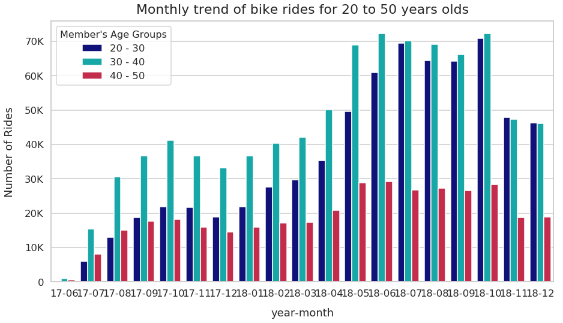

```python
Distribution_Monthly_Age_Groups()
```

## Bike Usage Times

- The following heat map shows subscribers peak usage between commute hours of 7am-9am and 4pm-6pm.
- For customers, the bike sharing service is more popular during the weekends on Saturday and Sunday.

```python
def bike_usage_times():
    subscriber_hour_df = df_copy[(df_copy['member_age']>=20) & (df_copy['member_age']<50)
                                  &(df_copy['start_time_hour']>5)&(df_copy['user_type']=='Subscriber')
                                 ].groupby(['start_time_week_abbr', 'start_time_hour']).agg({'bike_id' : 'count'}).rename(columns={'bike_id':'count'}).reset_index()
    subscriber_hour_df['start_time_week_abbr'] = pd.Categorical(subscriber_hour_df['start_time_week_abbr'], categories=[ 'Sun','Mon','Tue','Wed','Thu','Fri','Sat'], ordered=True)
    subscriber_hour_df['count_perc'] = subscriber_hour_df['count'].apply(lambda x: (x/subscriber_hour_df['count'].sum())*100)
    subscriber_hour_df['rank'] = subscriber_hour_df['count_perc'].rank(ascending=False).astype(int)
    subscriber_hour_df_pivoted = subscriber_hour_df.pivot_table(index='start_time_hour', columns='start_time_week_abbr', values='rank')
    customer_hour_df = df_copy[(df_copy['member_age']>=20) & (df_copy['member_age']<40)
                                  &(df_copy['start_time_hour']>5)&(df_copy['user_type']=='Customer')
                                 ].groupby(['start_time_week_abbr', 'start_time_hour']).agg({'bike_id' : 'count'}).rename(columns={'bike_id':'count'}).reset_index()
    customer_hour_df['start_time_week_abbr'] = pd.Categorical(customer_hour_df['start_time_week_abbr'], categories=['Mon','Tue','Wed','Thu','Fri','Sat', 'Sun'], ordered=True)
    customer_hour_df['count_perc'] = customer_hour_df['count'].apply(lambda x: (x/customer_hour_df['count'].sum())*100) #male
    customer_hour_df['rank'] = customer_hour_df['count_perc'].rank(ascending=False).astype(int)
    customer_hour_df_pivoted = customer_hour_df.pivot_table(index='start_time_hour', columns='start_time_week_abbr', values='rank').astype(int)
    plt.figure(figsize=(15,10))
    plt.subplot(121)
    plt.suptitle('Hourly Usage and Frequency for 20-50 Age Group', fontsize=22)
    sns.heatmap(subscriber_hour_df_pivoted, fmt='d', annot=True, cmap='YlGnBu_r', annot_kws={"size": 12})
    plt.title("Subscribers Bike Usage", y=1.015)
    plt.xlabel('Day of the Week', labelpad=15)
    plt.ylabel('Hour (Military)', labelpad=15)
    plt.yticks(rotation=360)
    plt.subplot(122)
    sns.heatmap(customer_hour_df_pivoted, fmt='d', annot=True, cmap='YlGnBu_r', annot_kws={"size": 12}, cbar_kws={'label': 'Frequency Ranking'})
    plt.title("Customers Bike Usage", y=1.015)
    plt.xlabel('Day of the Week', labelpad=15)
    plt.ylabel(' ')
    plt.yticks(rotation=360)
```

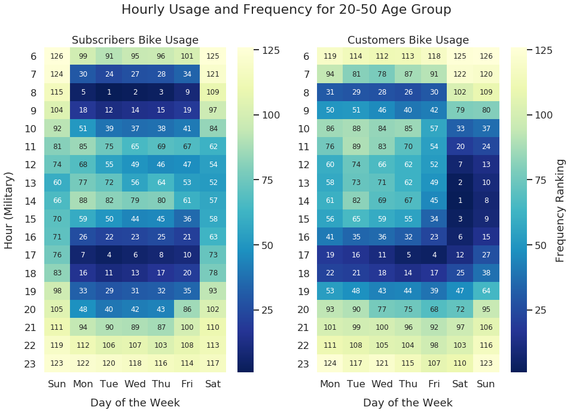

```python
bike_usage_times()
```

## Ride Duration per Rider Type and Gender

Non-subscriber female riders appear to take longer bike trips. While members trip time is about the same.

```python
def Ride_Duration_Rider_Type_and_Gender():
    # Ride Duration per Rider Type and Gender
    g = sns.catplot(data=df_copy, x='user_type', y="duration_sec", hue="member_gender", kind="bar")
    g.set_axis_labels("User Type", "Ride Duration in Seconds")
    g._legend.set_title('Gender')
    g.fig.suptitle('Ride Duration per Rider Type and Gender', y=1.03, fontsize=15, fontweight='semibold');
```

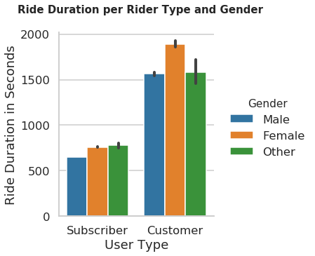

```python
Ride_Duration_Rider_Type_and_Gender()
```